# Predicting the Chance of Winning in Valorant

Colin Nguyen, Christina Ngo

### Introduction

Valorant is a popular first-person shooter game developed and published by Riot Games. It was released in 2020 and has quickly become a fan favorite for its fast-paced gameplay and strategic elements. In the game, players assume the role of agents, characters with unique abilities and weapons, who compete against each other in a variety of game modes. Valorant has gained a following for its intense and competitive nature, making it a popular choice for both casual and professional players. For more information can be found [here](https://playvalorant.com/en-us/).

Strategy, teamwork, and individual skill is highly valued in Valorant that can help win many games. Developing a good game plan and working well with your teammates can give you a significant advantage over the other team. There are much more factors that will dictate a win or loss in a match, which this tutorial will cover.

Our goal is to tidy the in-game data given to us and provide a valuable insight into which agents will affect your win percentages on games. Having a good understanding of the game and your own abilities, as well as those of your opponents, can help you make better decisions and improve your chances of victory. Lastly, knowing what gun to use and having good aim and being able to make quick, accurate shots can be crucial in winning gunfights and in clutching moments to defuse bombs.

For readers unfamiliar with this game, we hope this analysis will make you interested in trying out Valorant and provide some evidence on which agents are best to pick starting out as a new player. Additionally helping you choose which gun best to use to help increase your chances of winning. For experienced players, we hope to show interesting unknown statistics and maybe even give them new things to try when they play.

### Grabbing Data

##### Getting Started

To start our project, we start by looking for data on Valorant and players. Riot Games does offer their API keys out to developers, but unfortunately, Riot was more strict with Valorant data in comparison to their other games. We were forced to look elsewhere and luckily, we were able to find a data on Kaggle that contains data of player's statistics in mostly Diamond 3 and above in Valorant in Act 3 Chapter 4 to make our data more usable.

```python
import pandas as pd
import matplotlib.pyplot as plt
import numpy as np
import seaborn as sns
import math
import decimal
from sklearn import preprocessing
from sklearn.preprocessing import StandardScaler
from sklearn import model_selection
from sklearn.preprocessing import MinMaxScaler
from sklearn import linear_model
from sklearn import preprocessing
from sklearn.preprocessing import LabelEncoder
```

```python
val_stats = pd.read_csv("val_stats.csv")

val_stats.head()
```

|  | region | name | tag | rating | damage_round | headshots | headshot_percent | aces | clutches | flawless | ... | gun2_name | gun2_head | gun2_body | gun2_legs | gun2_kills | gun3_name | gun3_head | gun3_body | gun3_legs | gun3_kills |
| --- | --- | --- | --- | --- | --- | --- | --- | --- | --- | --- | --- | --- | --- | --- | --- | --- | --- | --- | --- | --- | --- |
| 0 | NaN | ShimmyXD | #NA1 | Radiant | 135.8 | 992 | 24.9 | 0 | 140 | 80 | ... | Phantom | 33 | 62 | 5 | 220 | Classic | 36 | 60 | 3 | 147 |
| 1 | NaN | XSET Cryo | #cells | Radiant | 170.3 | 879 | 28.3 | 2 | 122 | 94 | ... | Operator | 8 | 91 | 0 | 226 | Phantom | 32 | 63 | 5 | 137 |
| 2 | NaN | PuRelittleone | #yoruW | Radiant | 147.5 | 720 | 24.0 | 3 | 117 | 59 | ... | Phantom | 36 | 61 | 3 | 231 | Operator | 8 | 91 | 1 | 102 |
| 3 | NaN | Boba | #0068 | Radiant | 178.2 | 856 | 37.3 | 3 | 83 | 49 | ... | Sheriff | 48 | 51 | 1 | 48 | Phantom | 44 | 56 | 0 | 36 |
| 4 | NaN | i love mina | #kelly | Radiant | 149.8 | 534 | 24.4 | 2 | 71 | 38 | ... | Spectre | 21 | 71 | 8 | 65 | Operator | 8 | 92 | 0 | 64 |

5 rows × 38 columns

### Tidying up the Data

```python
# grabbing all the unique regions
val_stats.region.unique()
```

```
array([nan, 'EU', 'AP', 'KR', 'BR', 'LAT'], dtype=object)
```

```python
# filling any NaN with NA to show proper region
val_stats['region'] = val_stats['region'].fillna('NA')
```

```python
# setting index to region to make it easier to drop other regions
val_stats = val_stats.set_index("region")
```

```python
# dropping regions
val_stats = val_stats.drop(['EU', 'AP', 'KR', 'BR', 'LAT'])
```

```python
# removing columns to help convert strings to numbers
val_stats = val_stats.replace(',','', regex=True)
```

```python
val_stats.columns
```

```
Index(['name', 'tag', 'rating', 'damage_round', 'headshots',
       'headshot_percent', 'aces', 'clutches', 'flawless', 'first_bloods',
       'kills', 'deaths', 'assists', 'kd_ratio', 'kills_round', 'most_kills',
       'score_round', 'wins', 'win_percent', 'agent_1', 'agent_2', 'agent_3',
       'gun1_name', 'gun1_head', 'gun1_body', 'gun1_legs', 'gun1_kills',
       'gun2_name', 'gun2_head', 'gun2_body', 'gun2_legs', 'gun2_kills',
       'gun3_name', 'gun3_head', 'gun3_body', 'gun3_legs', 'gun3_kills'],
      dtype='object')
```

Going through the columns, we noticed there were a few that columns that wouldn't provide much use to us. This was mainly items, such as name and tag. We have also dropped the columns agent_2 and agent_3 to only focus on agents that players mostly pick. After a little consideration, we decided to also drop anything related to gun_2 and gun_3. It seemed more beneficial to focus on the main choice of weapon as it's the choice people go for most. Gun2 and gun3 would mainly be pistols and save-round guns, which don't provide the best accuracy when shooting sometimes. We also wanted to settle the debate: vandal or phantom.

```python
# dropping columns that we don't need
val_stats = val_stats.drop(columns = ['name', 'tag', 'gun2_name', 'gun3_name', 'gun2_body','gun3_body', 'gun2_legs', 'gun3_legs','gun2_kills','gun3_kills','agent_2','agent_3','gun2_head','gun3_head'])
```

```python
val_stats
```

| region | rating | damage_round | headshots | headshot_percent | aces | clutches | flawless | first_bloods | kills | deaths | ... | most_kills | score_round | wins | win_percent | agent_1 | gun1_name | gun1_head | gun1_body | gun1_legs | gun1_kills |
| --- | --- | --- | --- | --- | --- | --- | --- | --- | --- | --- | --- | --- | --- | --- | --- | --- | --- | --- | --- | --- | --- |
| NA | Radiant | 135.8 | 992 | 24.9 | 0 | 140 | 80 | 161 | 1506 | 1408 | ... | 29 | 208.8 | 59 | 59.6 | Fade | Vandal | 35 | 59 | 5 | 802 |
| NA | Radiant | 170.3 | 879 | 28.3 | 2 | 122 | 94 | 316 | 1608 | 1187 | ... | 32 | 270.6 | 52 | 65.8 | Chamber | Vandal | 41 | 56 | 3 | 689 |
| NA | Radiant | 147.5 | 720 | 24.0 | 3 | 117 | 59 | 216 | 1115 | 1064 | ... | 39 | 227.8 | 42 | 65.6 | Yoru | Vandal | 38 | 57 | 4 | 444 |
| NA | Radiant | 178.2 | 856 | 37.3 | 3 | 83 | 49 | 235 | 1134 | 812 | ... | 37 | 277.0 | 32 | 62.8 | Jett | Vandal | 51 | 47 | 2 | 754 |
| NA | Radiant | 149.8 | 534 | 24.4 | 2 | 71 | 38 | 137 | 869 | 781 | ... | 29 | 230.9 | 32 | 62.8 | Jett | Vandal | 36 | 60 | 4 | 419 |
| ... | ... | ... | ... | ... | ... | ... | ... | ... | ... | ... | ... | ... | ... | ... | ... | ... | ... | ... | ... | ... | ... |
| NA | Immortal 1 | 140.8 | 144 | 17.4 | 1 | 19 | 18 | 44 | 320 | 286 | ... | 29 | 218.0 | 9 | 45.0 | Chamber | Vandal | 23 | 68 | 9 | 147 |
| NA | Immortal 1 | 141.9 | 700 | 12.4 | 3 | 155 | 73 | 198 | 1605 | 1556 | ... | 33 | 218.3 | 43 | 43.0 | Yoru | Phantom | 19 | 74 | 7 | 752 |
| NA | Immortal 1 | 151.7 | 759 | 23.6 | 4 | 99 | 60 | 212 | 1124 | 1027 | ... | 32 | 235.1 | 29 | 44.6 | Jett | Vandal | 33 | 62 | 5 | 680 |
| NA | Immortal 1 | 139.5 | 366 | 19.8 | 0 | 60 | 30 | 68 | 605 | 630 | ... | 31 | 208.1 | 21 | 50.0 | Sova | Vandal | 28 | 67 | 4 | 240 |
| NA | Immortal 3 | 139.2 | 859 | 28.5 | 1 | 126 | 47 | 157 | 1290 | 1324 | ... | 27 | 208.3 | 37 | 44.0 | Chamber | Vandal | 40 | 56 | 4 | 646 |

20865 rows × 23 columns

# Exploring the Data

### Getting to Know All The Agents

In Valorant, each player chooses a character known as an "Agent" to play as, each with their own unique abilities and role within the team. There are currently about 20 agents in Valorant however with our dataset only includes 19, since we were not able to get the latest dataset with the newest updates. Moving on, each with agents own unique abilities and playstyle. The 20 agents in Valorant are broadly classified into 4 big roles that will affect your playstyle and gameplay.

Duelists are agents that excel at one-on-one fights and can hold their own against multiple enemies. They often have abilities that allow them to sustain themselves in fights or deal high burst damage. They also create space for your team by entrying in for your team.

Initiators are agents that excel at starting fights and disrupting the enemy team's positioning. They often have abilities that allow them to close the distance quickly and get in close to engage the enemy. They provide information for your team in order to assist the team when charging into battle.

Sentinels are defensive agents that excel at controlling an area and protecting their team. They often have abilities that allow them to erect barriers or set up traps to control the battlefield. They can watch flanks, both on attack and defender rounds.

Controllers are agents that excel at disrupting the enemy team's positioning and denying areas of the map. They often have abilities that allow them to create obstacles or block off areas of the map.

Picking which agent is to play in a match is hard with all the possibilities, so we will create multiple bar graphs that would help show which agent is most popular for each role to help inexperienced players which agent they should pick. First we will make a new dataframe (grouping by agent and role), sum the number of agents been picked, wins, and calculate win ratios for each roles and popularity of each agents in every role, then show the relationships.

```python
# grabbing unique agents in the csv file
agents = val_stats.agent_1.unique()

# temp list to add into our dataframe
total_pick = []
# looping through all the agents
for agent in agents:
    all_agents = val_stats[val_stats['agent_1'] == agent]
    total = len(all_agents)
    # adding up the total amounts of times an agent as been picked
    total_pick.append(total)
# creating a new dataframe to add in our new column
agent_top = pd.DataFrame()
agent_top['Agents'] = agents
agent_top['Times Agent Picked'] = total_pick
```

```python
# grouping the agents by their respective roles and sorting the amount of times the agent has been picked
initiators = agent_top.loc[agent_top['Agents'].isin(["Fade","Skye","Sova","Breach","KAY/O"])]
initiators = initiators.sort_values(by='Times Agent Picked',ascending = False)

controllers = agent_top.loc[agent_top['Agents'].isin(["Brimstone","Astra","Omen","Viper"])]
controllers = controllers.sort_values(by='Times Agent Picked',ascending = False)

sentinels = agent_top.loc[agent_top['Agents'].isin(["Chamber","Cypher","Killjoy","Sage"])]
sentinels = sentinels.sort_values(by='Times Agent Picked',ascending = False)

duelists = agent_top.loc[agent_top['Agents'].isin(["Phoenix","Jett","Neon","Reyna","Yoru","Raze"])]
duelists = duelists.sort_values(by='Times Agent Picked',ascending = False)
```

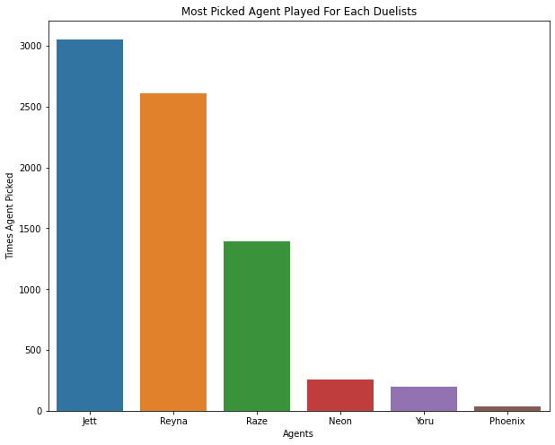

```python
# graphing the most picked duelists
plt.figure(figsize=(10,8))
plt.title('Most Picked Agent Played For Each Duelists')
sns.barplot(data=duelists, x='Agents',y='Times Agent Picked')
plt.show()
```

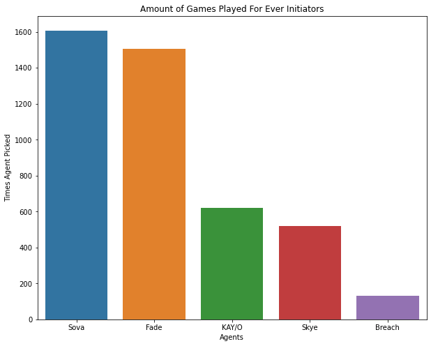

```python
# graphing the most picked initiators
plt.figure(figsize=(10,8))
plt.title('Amount of Games Played For Ever Initiators')
sns.barplot(data=initiators, x='Agents',y='Times Agent Picked')
plt.show()
```

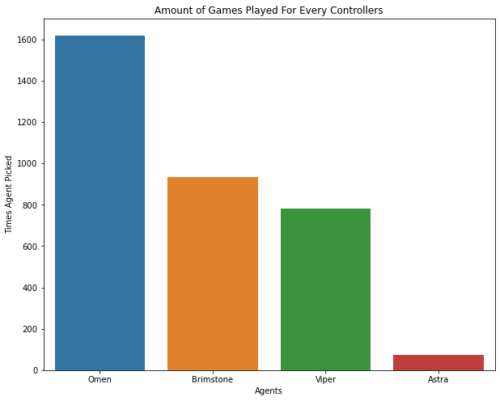

```python
# graphing the most picked controllers
plt.figure(figsize=(10,8))
plt.title('Amount of Games Played For Every Controllers')
sns.barplot(data=controllers, x='Agents',y='Times Agent Picked')
plt.show()
```

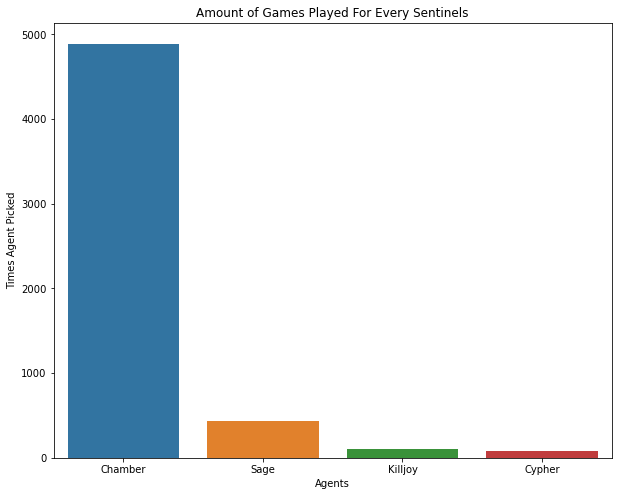

```python
# graphing the most picked sentinels
plt.figure(figsize=(10,8))
plt.title('Amount of Games Played For Every Sentinels')
sns.barplot(data=sentinels, x='Agents',y='Times Agent Picked')
plt.show()
```

### Agents Analysis

You can see that for the Duelist role, the three most played agent are Jett, Reyna, and Raze. For Initiators, the three most played agents are Sova, Fade, and KAY/O. For Controllers, the three most played agents are Omen, Brimstone, and Viper. Finally Sentinals, the three most played agents are Chamber, Sage, and Killjoy

There are agents that everyone loves playing because their playstyle best matches how they want to play. However, it doesn't mean that the agents is best in the current meta or in other words the best strategist to win games. So we will create a bar graph to show you which agents have the highest win percentage.

#### Total Games Played

We came to the realization that we only had the wins and each player's winning percentage, which would make it really hard to calculate data and analyze as we move forward. To calculate this, we divided the given win percentage of each user by 100. We used that number to divide wins to get total games that user had played in the Act.

```python
#  creating a new column for total games
val_stats['total_games'] = val_stats['wins']/(val_stats['win_percent']/100)
```

```python
# creating a list for total wins of each agent
total_wins = []
# looping through the agents
for agent in agents:
    all_agents = val_stats[val_stats['agent_1'] == agent]
    # summing up the wins for each agent
    total = all_agents['wins'].sum()
    total_wins.append(total)
# adding column into our dataframe
agent_top['Total of Wins'] = total_wins
```

```python
# creating a list for total games of each agent
total_games = []
# looping through the agents
for agent in agents:
    all_agents = val_stats[val_stats['agent_1'] == agent]
    # summing up the games played for each agent
    total = all_agents['total_games'].sum()
    total_games.append(total)
# adding column into our existing dataframe
agent_top['Total of games'] = total_games
# creating a temp dataframe to reference the added columns for later use
final = pd.DataFrame
final = agent_top
```

Now that we have the total amount of wins for each agent and the total amount of games played for each agent. We can now find the win percentage of every agent by taking the amount of wins and dividing it by the amount of games played. Then we are able to graph the win percentages of every agent as a bar plot.

```python
total_win_per = []
for agent in agents:
    all_agents = final[final['Agents'] == agent]
    # getting the win percentage by dividing the total wins by total games
    # multiply 100 because we want number to be a percentage
    total = 100*(float(all_agents['Total of Wins']/all_agents['Total of games']))
    total_win_per.append(total)
# adding column into our dataframe to create bargraph
agent_top['Win Percentage'] = total_win_per
```

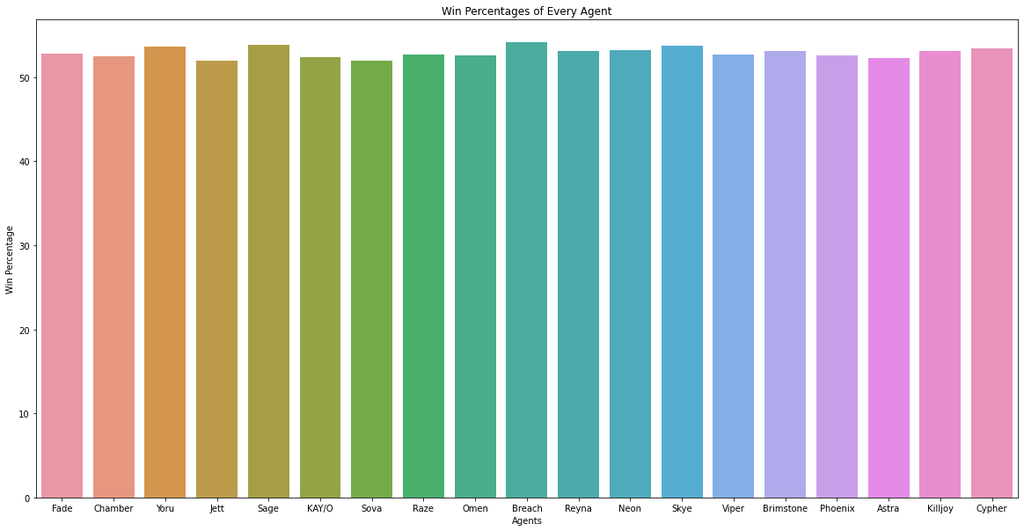

```python
# graphing all the agents win percentage
plt.figure(figsize=(20,10))
plt.title('Win Percentages of Every Agent')
sns.barplot(data=final, x='Agents',y='Win Percentage')
plt.show()
```

### Win Percentage Agents Analysis

From creating the bargraph above, we can see that every agent has a very similar win percentages. Even though some agents are played a lot more than others, however you can see that their win percentages are about equal in this dataset. This means that which agent you pick have little affect of your win percentage. Mastering the agent will better your chances of winning regardless of what is the current meta.

### Which Gun has the most kills

Moving on to which guns to use. Valorant is also a precise gunplay so we need to know which guns to use during our matches. We were provided with information from the players chosen primay used gun. We wanted to see which gun gets the most kills for each player on average. To do so, we iterated through each row and summed up totals based on the gun listed in the column "gun1_name". We divided the total by the number of users, who chose that specific gun.

```python
# grabbing the unique weapons from primary guns
weapons = val_stats.gun1_name.unique()
```

```python
# creating a new dataframe to hold information on weapons
temp = pd.DataFrame()
avg_kills = []

# iterating through the list of weapon choices
for weapon in weapons:
    weapon_data = val_stats[val_stats['gun1_name'] == weapon]

    # calculating the average kills each weapon gets
    weapon_data['gun1_kills'] = pd.to_numeric(weapon_data['gun1_kills'])
    total = weapon_data['gun1_kills'].sum()
    avg = float(total/len(weapon_data))

    avg_kills.append(avg)

# inserting new found data into the new df
temp['weapon'] = weapons
temp['avg kills'] = avg_kills
```

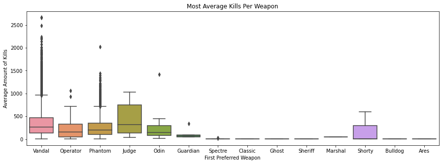

```python
# creating boxplot
x = val_stats['gun1_name']
y = pd.to_numeric(val_stats['gun1_kills'])

plt.figure(figsize=(15,5))
sns.boxplot(x, y, data=val_stats)
plt.title('Most Average Kills Per Weapon')
plt.xlabel('First Preferred Weapon')
plt.ylabel('Average Amount of Kills')
```

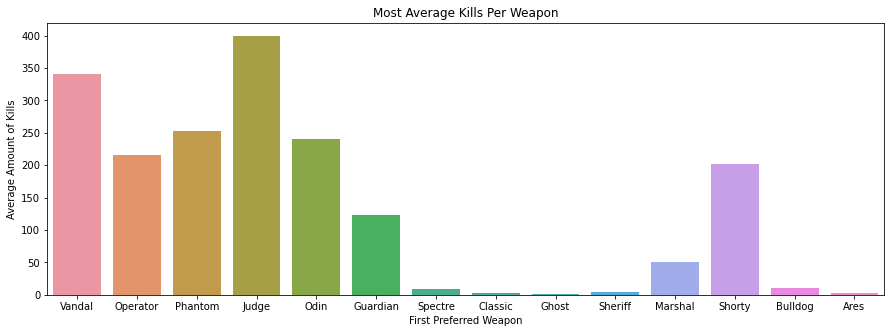

```python
# creating boxplot
plt.figure(figsize=(15,5))
sns.barplot("weapon", "avg kills", data=temp)
plt.title('Most Average Kills Per Weapon')
plt.xlabel('First Preferred Weapon')
plt.ylabel('Average Amount of Kills')
```

We want to acknowledge that this data might not be the most accurate as other guns, such as the Vandal and the Phantom, are picked more often in comparison to guns, such as the classic and ghost. To ensure that each gun was being fairly checked, we went ahead and normalized this data.

```python
# normalizing average kills column
temp['kills_norm'] = temp['avg kills'] /temp['avg kills'].abs().max()
```

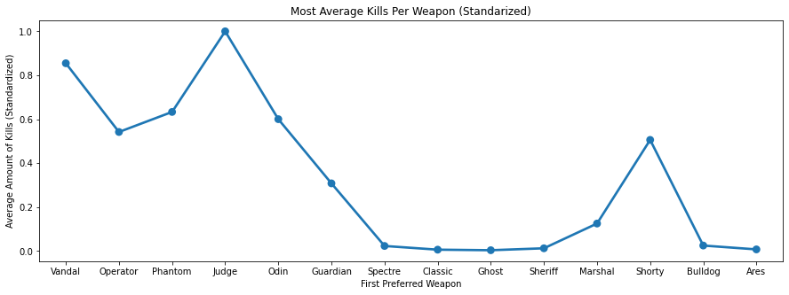

```python
# graphing standarized data of average kills
plt.figure(figsize=(15,5))
sns.pointplot(x="weapon", y="kills_norm", data=temp)
plt.title('Most Average Kills Per Weapon (Standarized)')
plt.xlabel('First Preferred Weapon')
plt.ylabel('Average Amount of Kills (Standardized)')
```

From this graph compared to our first bar graph, we're able to tell which guns genuinely have a higher average in comparison to other guns depending on how frequent the gun was picked. It's interesting to see that the data hasn't changed much after standarizing it. It's also quite unexpected that the judge still has a high average and it stays above 0, meaning its picked commonly. I thought it would be picked a lot less as we go up in ranks.

### Gun with the highest avgerage headshot

A lot of gunfights are easily decided by who gets the first headshot and who's more accurate with their gun. We were interested in seeing if possibly the gun picked might heavily influence whether you get more kills or not. We decided to calculate the average headshot each gun gets to see if it would.

```python
avg_head = []

# iterating through weapons and grabbing the average headshot of each gun
for weapon in weapons:
    weapon_data = val_stats[val_stats['gun1_name'] == weapon]

    # calculating average headshots per gun
    weapon_data['gun1_head'] = pd.to_numeric(weapon_data['gun1_head'])
    total = weapon_data['gun1_head'].sum()
    avg = float(total/len(weapon_data))

    avg_head.append(avg)

temp['avg headshots'] = avg_head
```

```python
# normalizing the data
temp['head_norm'] = temp['avg headshots'] /temp['avg headshots'].abs().max()
```

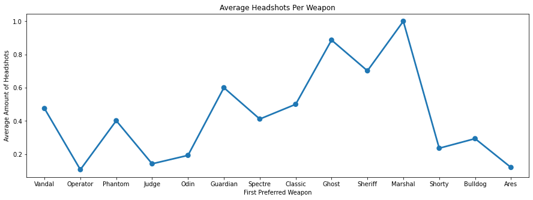

```python
plt.figure(figsize=(15,5))
sns.pointplot(x="weapon", y="head_norm", data=temp)
plt.title('Average Headshots Per Weapon')
plt.xlabel('First Preferred Weapon')
plt.ylabel('Average Amount of Headshots')
```

We notice that average headshots were surprisingly higher with pistols rather than a SMG like vandal and phantom. This probably has to do with less bullets per reload. I think it's important to note the averages between vandal and phantom as they are the most played guns. Vandal seems to have a higher headshot percentage for the reasons as mentioned above.

### Winning Percentage Based on Gun Choice

Moving on, we want to see if your primary gun choice will affect your win percentage and what gun is best to increase your chances of winning. In order to do so, we will calculate the win percentages based on the gun you use during a match. We will take the primary gun that players win with and divide that by the total amount of games the players have played to get the win percentage per gun.

```python
win_gun = []

# calculating win percentage per gun
for weapon in weapons:
    weapon_data = val_stats[val_stats['gun1_name'] == weapon]
    total = weapon_data['total_games'].sum()
    wins = weapon_data['wins'].sum()
    winning_percent = (wins/total)*100

    win_gun.append(winning_percent)

    if weapon == "Classic" or weapon == "Ghost":
        display(weapon_data)

temp['winper_gun'] = win_gun
```

| region | rating | damage_round | headshots | headshot_percent | aces | clutches | flawless | first_bloods | kills | deaths | ... | score_round | wins | win_percent | agent_1 | gun1_name | gun1_head | gun1_body | gun1_legs | gun1_kills | total_games |
| --- | --- | --- | --- | --- | --- | --- | --- | --- | --- | --- | --- | --- | --- | --- | --- | --- | --- | --- | --- | --- | --- |
| NA | Immortal 1 | 134.4 | 7 | 19.4 | 0 | 0 | 1 | 2 | 15 | 13 | ... | 191.8 | 0 | 0.0 | Chamber | Classic | 0 | 100 | 0 | 3 | NaN |
| NA | Immortal 1 | 87.9 | 7 | 26.2 | 0 | 0 | 0 | 2 | 8 | 14 | ... | 143.8 | 0 | 0.0 | Sova | Classic | 75 | 25 | 0 | 2 | NaN |

2 rows × 24 columns

| region | rating | damage_round | headshots | headshot_percent | aces | clutches | flawless | first_bloods | kills | deaths | ... | score_round | wins | win_percent | agent_1 | gun1_name | gun1_head | gun1_body | gun1_legs | gun1_kills | total_games |
| --- | --- | --- | --- | --- | --- | --- | --- | --- | --- | --- | --- | --- | --- | --- | --- | --- | --- | --- | --- | --- | --- |
| NA | Immortal 1 | 7.3 | 1 | 20.0 | 0 | 2 | 1 | 0 | 1 | 10 | ... | 12.4 | 0 | 0.0 | Omen | Ghost | 100 | 0 | 0 | 1 | NaN |
| NA | Immortal 1 | 104.2 | 4 | 18.2 | 0 | 0 | 0 | 0 | 7 | 10 | ... | 142.5 | 0 | 0.0 | Sova | Ghost | 33 | 67 | 0 | 2 | NaN |

2 rows × 24 columns

I wanted to see the results of the win percentage of Ghost and Classic pistol because the dataframe had NaN for those two guns. Then I dropped the NaN from the dataframe.

```python
temp.dropna()
```

|  | weapon | avg kills | kills_norm | avg headshots | head_norm | winper_gun |
| --- | --- | --- | --- | --- | --- | --- |
| 0 | Vandal | 341.285381 | 0.854666 | 35.621704 | 0.474956 | 52.483762 |
| 1 | Operator | 216.383178 | 0.541879 | 8.000000 | 0.106667 | 53.805290 |
| 2 | Phantom | 252.798987 | 0.633074 | 30.103797 | 0.401384 | 52.879999 |
| 3 | Judge | 399.320000 | 1.000000 | 10.640000 | 0.141867 | 52.481552 |
| 4 | Odin | 239.681818 | 0.600225 | 14.454545 | 0.192727 | 52.519681 |
| 5 | Guardian | 123.000000 | 0.308024 | 45.000000 | 0.600000 | 51.339093 |
| 6 | Spectre | 9.230769 | 0.023116 | 30.846154 | 0.411282 | 55.555556 |
| 9 | Sheriff | 5.000000 | 0.012521 | 52.625000 | 0.701667 | 50.000000 |
| 10 | Marshal | 50.000000 | 0.125213 | 75.000000 | 1.000000 | 38.500000 |
| 11 | Shorty | 202.000000 | 0.505860 | 17.666667 | 0.235556 | 57.742978 |
| 12 | Bulldog | 10.000000 | 0.025043 | 22.000000 | 0.293333 | 33.300000 |
| 13 | Ares | 3.000000 | 0.007513 | 9.000000 | 0.120000 | 100.000000 |

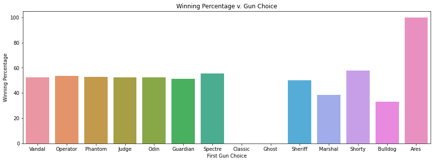

```python
# graph the winning percentages based on gun choices
plt.figure(figsize=(15,5))
sns.barplot(data=temp, x='weapon', y='winper_gun')
plt.title("Winning Percentage v. Gun Choice")
plt.xlabel("First Gun Choice")
plt.ylabel("Winning Percentage")
```

### Winning Percentage Based on Guns Analysis

As you can see in the bargraph above, the best winning percentage with a gun is the Ares. Keep in mind that the Ares has the highest win percentage because very few players use that gun as their primary so take that with a grain of salt. The most used gun in the Vandal with an average of 35.6% headshot rate. The second most used gun is the Phantom with an average of 30.1% headshot rate. The Vandal has a slower firerate with higher recoil, and is one shot kill to the head with only 25 bullets in its magazine. Phantom has a faster firerate, has damage fall off so its not one shot kill to the head, less recoil, and 30 bullets in its magazine. With our results from the graphs, Phantom is a better gun to use for inexperienced players since the charts show that it has a higher win percentage. Using our data or future data, you can graph each ranks best guns to use.

### Winning percentage Based on Ranks

Now, we want to compare the win percentages based on ranks to see if rank affect your win percentage. Keep in mind that the dataset is majority Radiants, Immortals, and Diamonds, so the data is a bit skewed since there are a few Silver and Golds.

To get our win percentage based on people's ranks, we will go through our dataframe and total up the wins for each rank. Then we will divide by the total amount of games that have been played. We will then multiple that number by 100 to get the actual percentage.

After getting the winning percentage of each rank, we will plot it as a bargraph to compare the winning percentage in each ranks.

```python
# grabbing the unique list of all of the possible ratings in this dataset
ratings = val_stats.rating.unique()
```

```python
# creating a list to store all of the winning percentage of each rank
rating = pd.DataFrame()
win_rating = []
rank = []

# iterating through each possible rank and grabbing the data pertaining to that rank
for rating in ratings:
    rank_data = val_stats[val_stats['rating']==rating]
    wins = rank_data['wins'].sum()
    total = rank_data['total_games'].sum()

    # calculating winning percentages based on ranks
    win_per = (wins/total)*100

    rank.append(str(rating))
    win_rating.append(win_per)
```

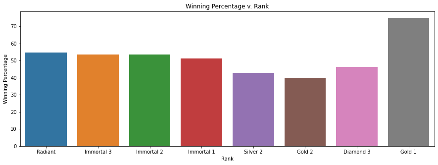

```python
# graphing winning percentage v. rank
plt.figure(figsize=(15,5))
sns.barplot(rank, win_rating)
plt.title("Winning Percentage v. Rank")
plt.xlabel("Rank")
plt.ylabel("Winning Percentage")
```

## Predicting Independent Variable that Influence Data

In this section, we want to see how your kill-death ratio will affect your chances you winning your matches. Theres a variety of predictions models we could use but given the amount of data given to us, we will solely focus on linear regression.

First, we are going to graph the kill-death ratio as the x axis and win percent as the y axis. We will then implement a line regression to predict how kill-death ratio can affect the chances of you winning.

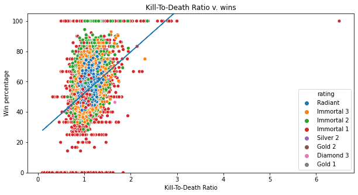

```python
# graphed winning percentages as we get higher k/d ratios
plt.figure(figsize=(10,5))
sns.scatterplot(x="kd_ratio", y="win_percent", data=val_stats, hue='rating')

x = val_stats['kd_ratio']
y = val_stats['win_percent']

# graphing linear regression
m, b = np.polyfit(x,y,1)
plt.plot(x, m*x+b)
plt.ylim((0,105))
plt.title('Kill-To-Death Ratio v. wins')
plt.xlabel('Kill-To-Death Ratio')
plt.ylabel('Win percentage')
```

### Winning percentage Based on Kill-Death Ratio Analysis

As you can see in the graph above with the linear regression line. Higher your Kill to death ratio, the higher percentage you will win your games. This applies to all ranks of Valorant players as the ranks in the data shows their kill death ratio based on their win percentage.

### Does headshot percentage have an influence on Winning?

Now in this last section, we will hypothesis to test if your headshot percentage rate affect your chances of winning. We will first graph a scatterplot with headshot percentage as the x value and win percentage as the y axis. Then we will implement a linear regression line to predict and see if your headshot percentage rate affect your win percentage.

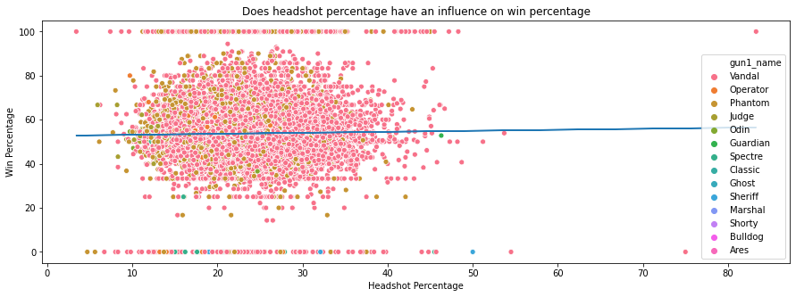

```python
# graphing headshots
x = val_stats['headshot_percent']
y = val_stats['win_percent']

plt.figure(figsize=(15,5))
sns.scatterplot(data=val_stats, x="headshot_percent", y="win_percent", hue="gun1_name")

#graphing linear regression
m, b = np.polyfit(x,y,1)
plt.plot(x, m*x+b)

plt.title('Does headshot percentage have an influence on win percentage')
plt.xlabel('Headshot Percentage')
plt.ylabel('Win Percentage')
```

### Headshot percentage v Winning Percentage Analysis

From the scatter plot above, we seem to found that the regression line is horizontal. In other words, the chances of you winning a game does not change regardless of how many headshots you hit. This could indicate that your headshot percentage does is not a significant factor in determing the chances of you winning the game. Winning a game is more than hitting headshots, since Valorant is a tactical team game.

# Conclusion and Further Exploration

This game, Valorant, is extremely popular and relatively new, so it's rare to see analysts releasing in-game data to the public. However, we were fortunate enough to come across a large data dump on the game and used it as part of our data science course (CMSC320) to gain a better understanding of the game and its complexities. Through this tutorial, we aimed to provide valuable insights and tips for both experienced and inexperienced players, covering topics such as the effectiveness of certain guns (e.g. Vandal versus Phantom) and the impact of headshot rate on win percentage, as well as which agents to choose in matches. While we were able to delve into some of the more popular questions about Valorant, there is still much data left to explore. This tutorial merely touches on the vast amount of data that game developers and analysts must consider when creating and analyzing games like Valorant. We hope you found the information useful!

For more information of our data we used for this tutorical click [here](https://www.kaggle.com/datasets/aliibrahim10/valorant-stats?resource=download)